# AI video-generation discourse analysis

Eliana

2026-05-01

# Hypotheses

H1 Discourse source is associated with realism/authenticity framing.  
H2 Discourse source is associated with human creativity/cultural value framing.  
H3 Discourse source is associated with production/control framing.

# Findings

## Hypothesis 1

```
## # A tibble: 2 × 3
##   discourse_source realism_benefit realism_concern
##   <chr>                      <dbl>           <dbl>
## 1 official                  0.408           0.0132
## 2 user                      0.0467          0.133
```

```
##
##  Pearson's Chi-squared test with Yates' continuity correction
##
## data:  d_ai$discourse_source and d_ai$realism_benefit_presence
## X-squared = 44.511, df = 1, p-value = 0.00000000002529
```

```
##
##  Pearson's Chi-squared test with Yates' continuity correction
##
## data:  d_ai$discourse_source and d_ai$realism_concern_presence
## X-squared = 7.2761, df = 1, p-value = 0.006988
```

We found that discourse source is associated with both realism/authenticity benefit framing, X2(df = 1, n = 226) = 44.51, p < .001, and realism/authenticity concern framing, X2(df = 1, n = 226) = 7.28, p = .007. Official discourse was more likely to benefit-frame realism/authenticity (40.8%) than user discourse (4.7%), whereas user discourse was more likely to concern-frame realism/authenticity (13.3%) than official discourse (1.3%).

## Hypothesis 2

```
## # A tibble: 2 × 3
##   discourse_source human_benefit human_concern
##   <chr>                    <dbl>         <dbl>
## 1 official                 0.329         0
## 2 user                     0.113         0.213
```

```
##
##  Pearson's Chi-squared test with Yates' continuity correction
##
## data:  d_ai$discourse_source and d_ai$human_benefit_presence
## X-squared = 14.107, df = 1, p-value = 0.0001727
```

```
##
##  Pearson's Chi-squared test with Yates' continuity correction
##
## data:  d_ai$discourse_source and d_ai$human_concern_presence
## X-squared = 17.173, df = 1, p-value = 0.00003412
```

We found that discourse source is associated with both human creativity/cultural benefit framing, X2(df = 1, n = 226) = 14.11, p < .001, and human creativity/cultural concern framing, X2(df = 1, n = 226) = 17.17, p < .001. Official discourse was more likely to benefit-frame human creativity/cultural value (32.9%) than user discourse (11.3%), whereas user discourse was more likely to concern-frame human creativity/cultural value (21.3%) than official discourse (0%).

## Hypothesis 3

```
## # A tibble: 2 × 3
##   discourse_source control_benefit control_concern
##   <chr>                      <dbl>           <dbl>
## 1 official                   0.697          0.0132
## 2 user                       0.147          0.127
```

```
##
##  Pearson's Chi-squared test with Yates' continuity correction
##
## data:  d_ai$discourse_source and d_ai$control_benefit_presence
## X-squared = 66.532, df = 1, p-value = 0.0000000000000003442
```

```
##
##  Pearson's Chi-squared test with Yates' continuity correction
##
## data:  d_ai$discourse_source and d_ai$control_concern_presence
## X-squared = 6.7113, df = 1, p-value = 0.00958
```

We found that discourse source is associated with both production/control benefit framing, X2(df = 1, n = 226) = 66.53, p < .001, and production/control concern framing, X2(df = 1, n = 226) = 6.71, p = .010. Official discourse was more likely to benefit-frame production/control (69.7%) than user discourse (14.7%), whereas user discourse was more likely to concern-frame production/control (12.7%) than official discourse (1.3%).

## Robustness checks for categorical comparisons

```
##
##  Fisher's Exact Test for Count Data
##
## data:  table(d_ai$discourse_source, d_ai$realism_benefit_presence)
## p-value = 0.00000000002995
## alternative hypothesis: true odds ratio is not equal to 1
## 95 percent confidence interval:
##  0.02506104 0.18110991
## sample estimates:
## odds ratio
## 0.07211636
```

```
##
##  Fisher's Exact Test for Count Data
##
## data:  table(d_ai$discourse_source, d_ai$realism_concern_presence)
## p-value = 0.002676
## alternative hypothesis: true odds ratio is not equal to 1
## 95 percent confidence interval:
##    1.761601 483.485963
## sample estimates:
## odds ratio
##   11.46417
```

```
##
##  Fisher's Exact Test for Count Data
##
## data:  table(d_ai$discourse_source, d_ai$human_benefit_presence)
## p-value = 0.0002144
## alternative hypothesis: true odds ratio is not equal to 1
## 95 percent confidence interval:
##  0.1218826 0.5529979
## sample estimates:
## odds ratio
##  0.2625324
```

```
##
##  Fisher's Exact Test for Count Data
##
## data:  table(d_ai$discourse_source, d_ai$human_concern_presence)
## p-value = 0.0000008442
## alternative hypothesis: true odds ratio is not equal to 1
## 95 percent confidence interval:
##  5.042619      Inf
## sample estimates:
## odds ratio
##        Inf
```

```
##
##  Fisher's Exact Test for Count Data
##
## data:  table(d_ai$discourse_source, d_ai$control_benefit_presence)
## p-value < 0.00000000000000022
## alternative hypothesis: true odds ratio is not equal to 1
## 95 percent confidence interval:
##  0.0362109 0.1525640
## sample estimates:
## odds ratio
## 0.07577663
```

```
##
##  Fisher's Exact Test for Count Data
##
## data:  table(d_ai$discourse_source, d_ai$control_concern_presence)
## p-value = 0.002753
## alternative hypothesis: true odds ratio is not equal to 1
## 95 percent confidence interval:
##    1.651453 456.990341
## sample estimates:
## odds ratio
##   10.80898
```

Results were substantively consistent in Fisher’s exact tests, including comparisons involving sparse cells: realism/authenticity benefit framing, p < .001; realism/authenticity concern framing, p = .003; human creativity/cultural benefit framing, p < .001; human creativity/cultural concern framing, p < .001; production/control benefit framing, p < .001; and production/control concern framing, p = .003.

## Overall pattern

```
## # A tibble: 2 × 7
##   discourse_source realism_benefit realism_concern human_benefit human_concern
##   <chr>                      <dbl>           <dbl>         <dbl>         <dbl>
## 1 official                  0.408           0.0132         0.329         0
## 2 user                      0.0467          0.133          0.113         0.213
## # ℹ 2 more variables: control_benefit <dbl>, control_concern <dbl>
```

```
## # A tibble: 12 × 3
##    discourse_source frame_type      proportion
##    <chr>            <ord>                <dbl>
##  1 official         realism_benefit     0.408
##  2 official         realism_concern     0.0132
##  3 official         human_benefit       0.329
##  4 official         human_concern       0
##  5 official         control_benefit     0.697
##  6 official         control_concern     0.0132
##  7 user             realism_benefit     0.0467
##  8 user             realism_concern     0.133
##  9 user             human_benefit       0.113
## 10 user             human_concern       0.213
## 11 user             control_benefit     0.147
## 12 user             control_concern     0.127
```

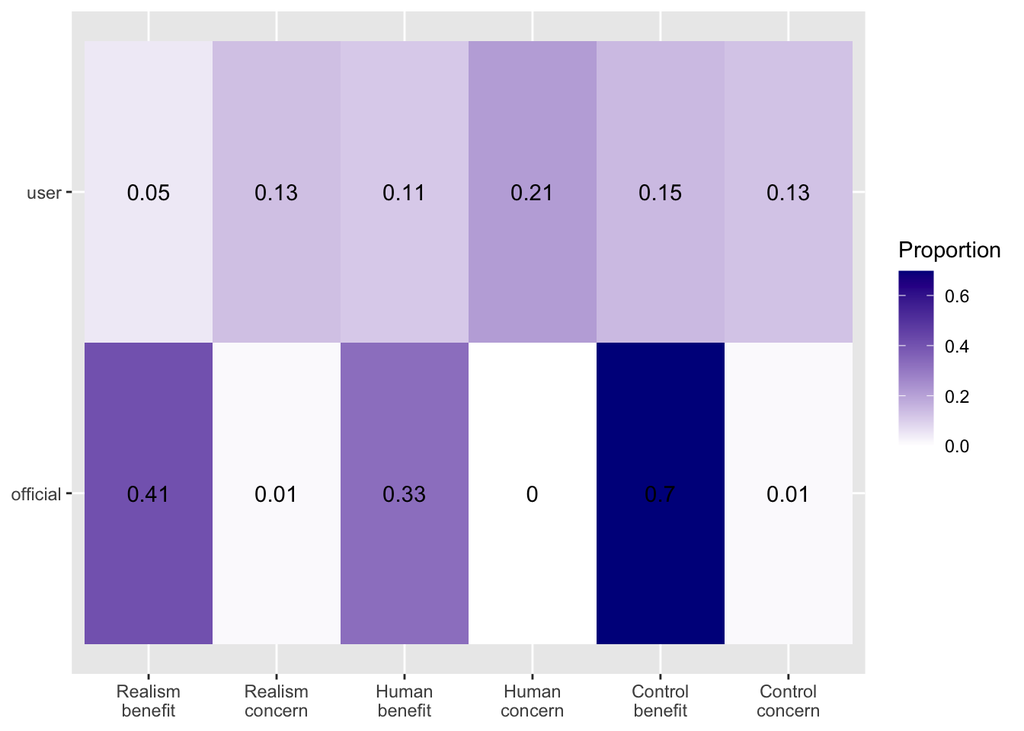

Across the six framing categories, the most prominent pattern in official discourse was production/control benefit framing (69.7%), followed by realism/authenticity benefit framing (40.8%) and human creativity/cultural benefit framing (32.9%). In user discourse, the highest proportion was human creativity/cultural concern framing (21.3%), followed by production/control benefit framing (14.7%), realism/authenticity concern framing (13.3%), and production/control concern framing (12.7%).

## Additional analysis

```
## # A tibble: 2 × 8
##   discourse_source     n M_benefit SD_benefit M_concern SD_concern M_balance
##   <chr>            <int>     <dbl>      <dbl>     <dbl>      <dbl>     <dbl>
## 1 official            76     1.43       0.806    0.0263      0.161     1.41
## 2 user               150     0.307      0.555    0.473       0.576    -0.167
## # ℹ 1 more variable: SD_balance <dbl>
```

```
##
##  Welch Two Sample t-test
##
## data:  benefit_score by discourse_source
## t = 10.956, df = 112.14, p-value < 0.00000000000000022
## alternative hypothesis: true difference in means between group official and group user is not equal to 0
## 95 percent confidence interval:
##  0.9236273 1.3314604
## sample estimates:
## mean in group official     mean in group user
##              1.4342105              0.3066667
```

```
##
##  Welch Two Sample t-test
##
## data:  concern_score by discourse_source
## t = -8.8494, df = 189.63, p-value = 0.0000000000000006155
## alternative hypothesis: true difference in means between group official and group user is not equal to 0
## 95 percent confidence interval:
##  -0.5466585 -0.3473765
## sample estimates:
## mean in group official     mean in group user
##             0.02631579             0.47333333
```

```
##
##  Welch Two Sample t-test
##
## data:  balance_score by discourse_source
## t = 13.16, df = 150.06, p-value < 0.00000000000000022
## alternative hypothesis: true difference in means between group official and group user is not equal to 0
## 95 percent confidence interval:
##  1.338146 1.810977
## sample estimates:
## mean in group official     mean in group user
##              1.4078947             -0.1666667
```

We found that official discourse had a significantly higher benefit score than user discourse, t(112.14) = 10.96, p < .001, while user discourse had a significantly higher concern score than official discourse, t(189.63) = -8.85, p < .001. Official discourse also had a significantly higher balance score than user discourse, t(150.06) = 13.16, p < .001, indicating that official texts were overall more benefit-oriented, whereas user texts were overall more concern-oriented.

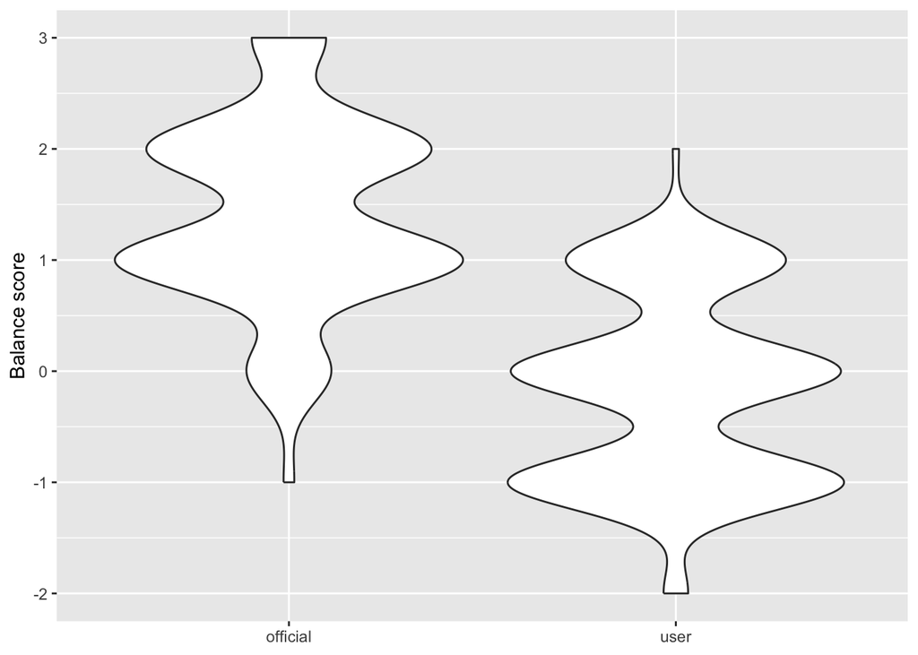

The violin plot shows that official discourse was more concentrated at positive balance scores, whereas user discourse was more concentrated around neutral or negative balance scores.

## Robustness checks for score comparisons

```
##
##  Wilcoxon rank sum test with continuity correction
##
## data:  benefit_score by discourse_source
## W = 9790.5, p-value < 0.00000000000000022
## alternative hypothesis: true location shift is not equal to 0
```

```
##
##  Wilcoxon rank sum test with continuity correction
##
## data:  concern_score by discourse_source
## W = 3374, p-value = 0.0000000003002
## alternative hypothesis: true location shift is not equal to 0
```

```
##
##  Wilcoxon rank sum test with continuity correction
##
## data:  balance_score by discourse_source
## W = 10129, p-value < 0.00000000000000022
## alternative hypothesis: true location shift is not equal to 0
```

The same overall pattern was also observed in Wilcoxon rank-sum tests: benefit score, W = 9790.5, p < .001; concern score, W = 3374, p < .001; and balance score, W = 10129, p < .001.

## Misalignment index

```
##   dimension official_benefit_gap user_concern_gap balanced_misalignment_hm
## 1   realism            0.3612281        0.1201754                0.1803507
## 2     human            0.2156140        0.2133333                0.2144676
## 3   control            0.5507018        0.1135088                0.1882219
```

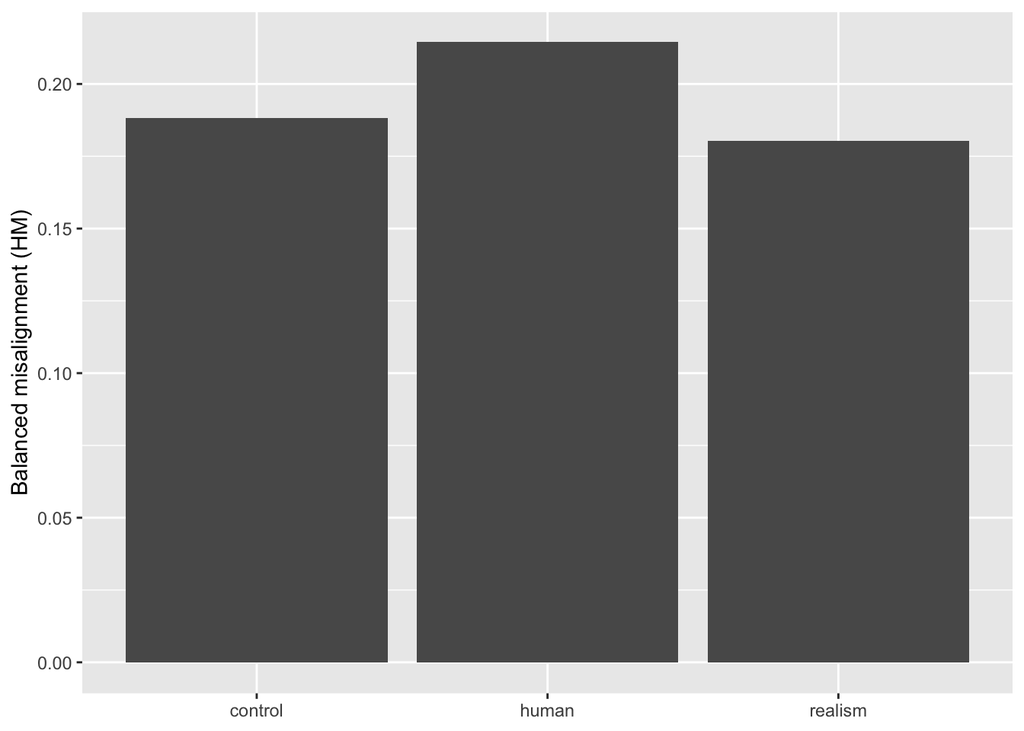

```
##            comparison    lower_95  upper_95
## 1 human_minus_control -0.08785871 0.1317328
## 2 human_minus_realism -0.06838895 0.1322825
```

To capture bidirectional misalignment more directly, a balanced misalignment measure was calculated using the harmonic mean of the official benefit gap and the user concern gap. By this measure, human creativity/cultural framing showed the highest balanced misalignment descriptively. However, bootstrap comparisons suggested caution in interpreting differences between dimensions, as the 95% confidence intervals for both the human-minus-control difference [-0.088, 0.132] and the human-minus-realism difference [-0.068, 0.132] crossed zero.